# Comparative Genomics Southern Flounder

# Receiving and demultiplexing libraries

**Demultiplex SFL-1 (HiSeq data for Mapping Familiy A):**

```
# create demultiplexed sequence folder
mkdir /home/soleary/FLOUNDER/SEQUENCES/SFL-1
cd /home/soleary/FLOUNDER/SEQUENCES/SFL-1

# demultiplex files
demultiplex.pl -i Demultiplex_SFL-1.txt -o Extract_SFL1.sh -p /home/soleary/FLOUNDER/SEQUENCES/SFL-1 -d /home/DATA/FLOUNDER/SFL-1
chmod 755 Extract_SFL1.sh
./Extract_SFL1.sh

# delete unnecessary files generated during demultiplexing
rm sample*
```

**Demultiplex SFL-3 (MiSeq data for reference construction):**

```
# create demultiplexed sequence folder
mkdir /home/soleary/FLOUNDER/SEQUENCES/SFL-3
cd /home/soleary/FLOUNDER/SEQUENCES/SFL-3

# demultiplex files
demultiplex.pl -i Demultiplex_SFL-3.txt -o Extract_SFL3.sh -p /home/soleary/FLOUNDER/SEQUENCES/SFL-3 -d /home/DATA/FLOUNDER/SFL-3
chmod 755 Extract_SFL3.sh
./Extract_SFL3.sh

# delete unnecessary files generated during demultiplexing
rm sample*
```

**Demultiplex SFL-FamB (HiSeq data for Mapping Family B)**

```
# create demultiplexed sequence folder
mkdir /home/soleary/FLOUNDER/SEQUENCES/SFL-FamB
cd /home/soleary/FLOUNDER/SEQUENCES/SFL-FamB

# demultiplex files
demultiplex.pl -i Demultiplex_SFL-FamB.txt -o Extract_SFL-FamB.sh -p /home/soleary/FLOUNDER/SEQUENCES/SFL-FamB -d /home/DATA/FLOUNDER/FamB
chmod 755 Extract_SFL-FamB.sh
./Extract_SFL-FamB.sh

# delete unnecessary files generated during demultiplexing
rm sample*

# rename all files to include library code
for file in * ; do mv "$file" "FamB_$file" ; done
```

Sequences of MiSeq and HiSeq libraries only need be quality trimmed once, this can be done in the `dDocent` pipeline before mapping.

# De novo reference creation

## Quality trimming & initial reference assembly in dDocent pipeline

Execute `dDocent` from within MiSeq Library folder (`SFL-3`) containing demultiplexed files and run initial assembly (no mapping or SNP variant calling necessary).

```
# initial reference assembly in dDocent
number of processors: 30
amount of memory: 100G
Quality trim: yes
assembly: yes
Type: OL
c = 0.88
K1 = 2
K2 = 2
```

The number of reads (contigs) contained in the reference depends on the data-cutoffs:

- minimum within individual coverage **K1**
- minimum number of individuals a read must occur in to be included **K2**
- % similarity for two stacks to be collapsed into one locus **c**

During reference assembly dDocent creates a file `uniqseq.data` containing the number of unique reads with 2X, 3X… coverage. dDocent will plot the distribution to aid in choosing a cut-off value.

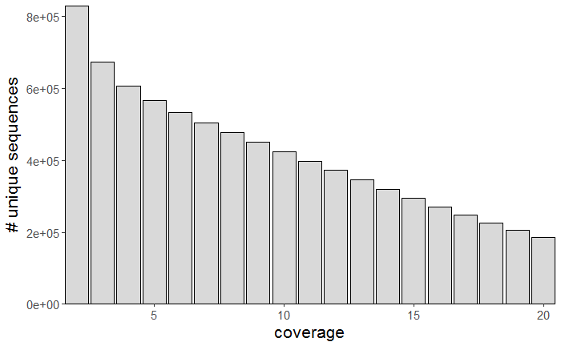

In addition, dDocent creates the file `uniqseq.peri.data` which contains the number of unique sequences that occur in more than X individuals. By choosing a cut-off value the user determines in how many individuals a unique sequence must occur in order for it to be included in the reference. In initial value of approx. 10% of individuals is sufficient for intial reference construction.

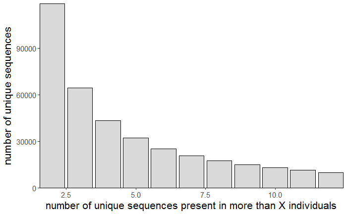

dDocent will generate a `fasta`-file containing all the loci included in the reference based on the chosen parameters. After initial reference construction, references for combinations of c, K1 and K2 should be generated and compared in terms of the number of loci and the quality of read mapping for individuals to be included in the data analysis.

## Identify values for c, K1 & K2

### Choose c parameter

#### Run `RefOpt`-Script

`RefOpt` used to create separate references at each similarity value (c = 0.8 - 0.98) for a given range of K1 = 1-10 (cut-off for within individual coverage) and K2 = 1-10 (minimum no. of individual read must occur in).

Before running dDocent ensure that `uniq.seq`-files (generated during intial dDocent run to create reference) are in same directory as reference optimizing script being executed from. Specificy `minK1`, `maxK1`, `minK2`, `maxK2`, `Assenmbly type` and `number of processors.

```
RefOpt 1 10 1 10 OL 35
```

Output file `kopt.data` contains the number of reads in reference for each c, K1, K2 combination.

#### Analyze `kopt`-output file

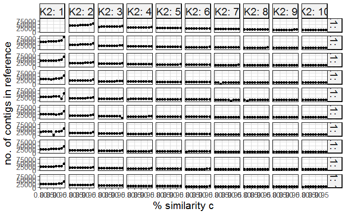

For K2 = 2, reads must occur in at least ~10% of individuals used to create the reference to be included.

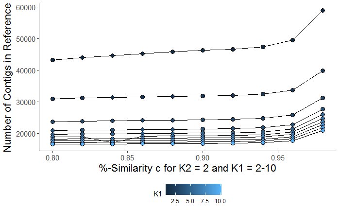

The lower the cut-off values from K1 and K2, the more likely loci will be included that are due to individual variability and are not informative on a population level (which can unnecessarily increase computational time).

If the cut-off values are too high loci that are informative might be excluded, which could lead to ascertainment bias. The optimum values for K1 and K2 are best determined by analyzing the mapping statistics of individuals mapped to references created for a combination of K1 and K2 values after an optimum c-value has been determined. The user will be able to compare the number of reads mapped in general, the number of reads mapped in pairs, the number of unmapped reads and the distribution of coverage to determine the best combinations of K.

In general, for a value c < 0.88 - 0.9 the variance in the number of reads obtained is negligible, while there is an observable jump in the number of reads in the reference for values of c > 0.95. This is due to over-splitting of loci at higher values. The higher c the more similar stacks of reads have to be in order to be combined into one locus. It’s better to “undersplit” and then filter out loci later (e.g. as paralogs).

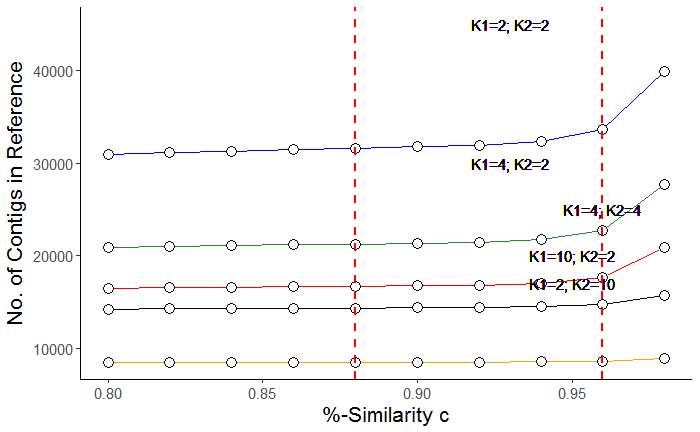

c-parameter chosen based on `SFL-kopt.data` results:

**c = 0.88**

### Choose K1 and K2 cut-off values

#### Assemble references for K1/K2 combinations

Create a new directory for each reference to be generated, here for K1 = 1-4 and K2 = 1-4:

```
mkdir /home/soleary/FLOUNDER/REF/REF11
mkdir /home/soleary/FLOUNDER/REF/REF12
mkdir /home/soleary/FLOUNDER/REF/REF13
mkdir /home/soleary/FLOUNDER/REF/REF14
mkdir /home/soleary/FLOUNDER/REF/REF21
mkdir /home/soleary/FLOUNDER/REF/REF22
mkdir /home/soleary/FLOUNDER/REF/REF23
mkdir /home/soleary/FLOUNDER/REF/REF24
mkdir /home/soleary/FLOUNDER/REF/REF31
mkdir /home/soleary/FLOUNDER/REF/REF32
mkdir /home/soleary/FLOUNDER/REF/REF33
mkdir /home/soleary/FLOUNDER/REF/REF34
mkdir /home/soleary/FLOUNDER/REF/REF41
mkdir /home/soleary/FLOUNDER/REF/REF42
mkdir /home/soleary/FLOUNDER/REF/REF43
mkdir /home/soleary/FLOUNDER/REF/REF44
```

In each Reference directory create soft links to the demultiplexed (and quality trimmed) fastq files from the REF library (possible to cut and paste all commands at once or create a bash script to execute).

```
ln -s /home/soleary/FLOUNDER/SEQUENCES/SFL-3/*.fq.gz /home/soleary/FLOUNDER/REF/REF11/
ln -s /home/soleary/FLOUNDER/SEQUENCES/SFL-3/*.fq.gz /home/soleary/FLOUNDER/REF/REF12/
ln -s /home/soleary/FLOUNDER/SEQUENCES/SFL-3/*.fq.gz /home/soleary/FLOUNDER/REF/REF13/
ln -s /home/soleary/FLOUNDER/SEQUENCES/SFL-3/*.fq.gz /home/soleary/FLOUNDER/REF/REF14/
ln -s /home/soleary/FLOUNDER/SEQUENCES/SFL-3/*.fq.gz /home/soleary/FLOUNDER/REF/REF21/
ln -s /home/soleary/FLOUNDER/SEQUENCES/SFL-3/*.fq.gz /home/soleary/FLOUNDER/REF/REF22/
ln -s /home/soleary/FLOUNDER/SEQUENCES/SFL-3/*.fq.gz /home/soleary/FLOUNDER/REF/REF23/
ln -s /home/soleary/FLOUNDER/SEQUENCES/SFL-3/*.fq.gz /home/soleary/FLOUNDER/REF/REF24/
ln -s /home/soleary/FLOUNDER/SEQUENCES/SFL-3/*.fq.gz /home/soleary/FLOUNDER/REF/REF31/
ln -s /home/soleary/FLOUNDER/SEQUENCES/SFL-3/*.fq.gz /home/soleary/FLOUNDER/REF/REF32/
ln -s /home/soleary/FLOUNDER/SEQUENCES/SFL-3/*.fq.gz /home/soleary/FLOUNDER/REF/REF33/
ln -s /home/soleary/FLOUNDER/SEQUENCES/SFL-3/*.fq.gz /home/soleary/FLOUNDER/REF/REF34/
ln -s /home/soleary/FLOUNDER/SEQUENCES/SFL-3/*.fq.gz /home/soleary/FLOUNDER/REF/REF41/
ln -s /home/soleary/FLOUNDER/SEQUENCES/SFL-3/*.fq.gz /home/soleary/FLOUNDER/REF/REF42/
ln -s /home/soleary/FLOUNDER/SEQUENCES/SFL-3/*.fq.gz /home/soleary/FLOUNDER/REF/REF43/
ln -s /home/soleary/FLOUNDER/SEQUENCES/SFL-3/*.fq.gz /home/soleary/FLOUNDER/REF/REF44/
```

Within each `REF*`-directory, execute `dDocent` to initiate a run which will create a reference for the chosen c-value and K1/K2 data cut-offs.

```
$ dDocent

# follow text prompts
Number of Processors: ##
Trimming? no
Assembly? yes
Type_of_Assembly? OL
Clustering_Similarity%: 0.88
Map reads? no
Email?
```

Remove the softlinks to the MiSeq data used for mapping and other files generated during `dDocent`-run in each folder, so that only `reference.fasta` and associated files and stats files remain:

```
rm /home/soleary/FLOUNDER/REF/REF11/*.fq.gz
rm /home/soleary/FLOUNDER/REF/REF11/*.seqs
rm /home/soleary/FLOUNDER/REF/REF11/*.fastq
rm /home/soleary/FLOUNDER/REF/REF11/*.gz
rm /home/soleary/FLOUNDER/REF/REF11/namelist
rm /home/soleary/FLOUNDER/REF/REF11/uniqCperindv
rm /home/soleary/FLOUNDER/REF/REF11/dDocent.runs
```

K1 and K2 are chosen based on mapping statistics of mapping HiSeq data to MiSeq data, i.e. HiSeq data needs to be demultiplexed and quality trimmed before it can be mapped. In each Reference directory create links to the demultiplexed (and quality trimmed) fastq files for approx. 20 individuals. The set of individuals should include individuals from as many locations as possible (use find replace to create set of commands to copy to each reference folder).

```
ln -s /home/soleary/FLOUNDER/SEQUENCES/SFL-2/HatchA_FL-FamA-F.*.fq.gz /home/soleary/FLOUNDER/REF/REF11/
ln -s /home/soleary/FLOUNDER/SEQUENCES/SFL-2/HatchA_FL-FamA-M.*.fq.gz /home/soleary/FLOUNDER/REF/REF11/
ln -s /home/soleary/FLOUNDER/SEQUENCES/SFL-2/HatchA_FL-FamB-077.*.fq.gz /home/soleary/FLOUNDER/REF/REF11/
ln -s /home/soleary/FLOUNDER/SEQUENCES/SFL-2/HatchA_FL-FamB-090.*.fq.gz /home/soleary/FLOUNDER/REF/REF11/
ln -s /home/soleary/FLOUNDER/SEQUENCES/SFL-2/HatchA_FL-FamB-097.*.fq.gz /home/soleary/FLOUNDER/REF/REF11/
ln -s /home/soleary/FLOUNDER/SEQUENCES/SFL-2/HatchA_FL-FamB-109.*.fq.gz /home/soleary/FLOUNDER/REF/REF11/
ln -s /home/soleary/FLOUNDER/SEQUENCES/SFL-2/HatchA_FL-FamB-129.*.fq.gz /home/soleary/FLOUNDER/REF/REF11/
ln -s /home/soleary/FLOUNDER/SEQUENCES/SFL-2/HatchA_FL-FamB-153.*.fq.gz /home/soleary/FLOUNDER/REF/REF11/
ln -s /home/soleary/FLOUNDER/SEQUENCES/SFL-2/HatchA_FL-FamB-163.*.fq.gz /home/soleary/FLOUNDER/REF/REF11/
ln -s /home/soleary/FLOUNDER/SEQUENCES/SFL-2/HatchA_FL-FamB-177.*.fq.gz /home/soleary/FLOUNDER/REF/REF11/
ln -s /home/soleary/FLOUNDER/SEQUENCES/SFL-1/SFL-1_SFL-A-020.*.fq.gz /home/soleary/FLOUNDER/REF/REF11/
ln -s /home/soleary/FLOUNDER/SEQUENCES/SFL-1/SFL-1_SFL-A-M1.*.fq.gz /home/soleary/FLOUNDER/REF/REF11/
ln -s /home/soleary/FLOUNDER/SEQUENCES/SFL-1/SFL-1_SFL-A-F1.*.fq.gz /home/soleary/FLOUNDER/REF/REF11/
ln -s /home/soleary/FLOUNDER/SEQUENCES/SFL-1/SFL-1_SFL-A-215.*.fq.gz /home/soleary/FLOUNDER/REF/REF11/
ln -s /home/soleary/FLOUNDER/SEQUENCES/SFL-1/SFL-1_SFL-A-213.*.fq.gz /home/soleary/FLOUNDER/REF/REF11/
ln -s /home/soleary/FLOUNDER/SEQUENCES/SFL-1/SFL-1_SFL-A-173.*.fq.gz /home/soleary/FLOUNDER/REF/REF11/
ln -s /home/soleary/FLOUNDER/SEQUENCES/SFL-1/SFL-1_SFL-A-153.*.fq.gz /home/soleary/FLOUNDER/REF/REF11/
ln -s /home/soleary/FLOUNDER/SEQUENCES/SFL-1/SFL-1_SFL-A-112.*.fq.gz /home/soleary/FLOUNDER/REF/REF11/
ln -s /home/soleary/FLOUNDER/SEQUENCES/SFL-1/SFL-1_SFL-A-66.*.fq.gz /home/soleary/FLOUNDER/REF/REF11/
ln -s /home/soleary/FLOUNDER/SEQUENCES/SFL-1/SFL-1_SFL-A-039.*.fq.gz /home/soleary/FLOUNDER/REF/REF11/
```

Execute `dDocent` from within each reference folder to initiate a run to map those individuals to the generated references.

```
# follow text prompts
Number of Processors: ##
Trimming? no
Assembly? no
Map reads? yes
Mapping_Match_Value: 1
Mapping_Mismatch_Value: 3
Mapping_GapOpen_Penalty: 5
Calling_SNPs? no
Email? name@provider
```

Remove softlinks to fasta-files

```
rm /home/soleary/FLOUNDER/REF/REF11/*.fq.gz
```

#### Query mapping statistics

During the mapping stage, `dDocent` calls `BWA` to map reads from the individuals in the folder to the generated MiSeqReference and create a `-RG.bam`-file for each individual. The second column of a BAM (or SAM) file contains FLAGs with binary encoded information on mapping, pairedness etc. that can be used to compare the mapping efficiency of the generated MiSeq references.

Count number of reads and mapped reads using `samtools idxstats <aln-RG.bam>` which will retrieve and print stats in the bam-file. The output is TAB-delimited with each line consisting of reference sequence name, sequence length, # mapped reads and # unmapped (empty) reads. `samtools` can also be be used to query `samtools flagstat file.bam` which returns an output containing the number of reads for which each flag is true.

```
# mapping statistics per loc per individual for REF21
cd /home/soleary/FLOUNDER/REF/REF12

for i in *.bam
do
samtools idxstats *.bam >> REF12.idxstats
samtools flagstat *.bam >> REF12.flagstats
done

samtools flagstat HatchA_FL-FamA-F-RG.bam > REF44.flagstats
samtools flagstat HatchA_FL-FamA-M-RG.bam >> REF44.flagstats
samtools flagstat HatchA_FL-FamB-077-RG.bam >> REF44.flagstats
samtools flagstat HatchA_FL-FamB-090-RG.bam >> REF44.flagstats
samtools flagstat HatchA_FL-FamB-097-RG.bam >> REF44.flagstats
samtools flagstat HatchA_FL-FamB-109-RG.bam >> REF44.flagstats
samtools flagstat HatchA_FL-FamB-129-RG.bam >> REF44.flagstats
samtools flagstat HatchA_FL-FamB-153-RG.bam >> REF44.flagstats
samtools flagstat HatchA_FL-FamB-163-RG.bam >> REF44.flagstats
samtools flagstat HatchA_FL-FamB-177-RG.bam >> REF44.flagstats
samtools flagstat SFL-1_SFL-A-020-RG.bam >> REF44.flagstats
samtools flagstat SFL-1_SFL-A-039-RG.bam >> REF44.flagstats
samtools flagstat SFL-1_SFL-A-66-RG.bam >> REF44.flagstats
samtools flagstat SFL-1_SFL-A-112-RG.bam >> REF44.flagstats
samtools flagstat SFL-1_SFL-A-153-RG.bam >> REF44.flagstats
samtools flagstat SFL-1_SFL-A-173-RG.bam >> REF44.flagstats
samtools flagstat SFL-1_SFL-A-213-RG.bam REF44.flagstats
samtools flagstat SFL-1_SFL-A-215-RG.bam >> REF44.flagstats
samtools flagstat SFL-1_SFL-A-F1-RG.bam REF44.flagstats
samtools flagstat SFL-1_SFL-A-M1-RG.bam >> REF44.flagstats
```

Generate `*.idxstats` and `*.flagstats` output files for each reference and copy into `data/REF`-folder on Windows machine. Appending the file results in the information per individual being printed in a new set of row being appended to the file, i.e. there will be as many rows for a given locus as individuals were mapped. The file can be re-formatted and summary statistics calculated using dplyr and tidyr.

```r
# create vectors of files to be imported, reference codes, K1 and K2, dataframe names
filenames <- list.files(path = "data/REF", pattern = "*.idxstats")
ref_code <- substr(filenames, 4, 5)
k1_list <- substr(filenames, 4, 4)
k2_list <- substr(filenames, 5, 5)
names <- substr(filenames, 1, 9)
# import data
for (i in names){
  filepath <- file.path("data/REF", paste(i, 'stats', sep =""))
  assign(i, read.csv(filepath, sep = "", header = FALSE,
                     col.names = c("Locus", "Length", "Reads_Mapped", 'blank')) %>%
           select(1:3))
  }
```

[output not shown]

```r
for (df in 1:length(dflist_flag)){
  x <- dflist_flag[[df]]
  x[['N_Reads']] <- as.numeric(x[['N_Reads']])
  dflist_flag[[df]] <- x
}
```

[output not shown]

With increasing values for K1 and K2 less contigs have sufficient coverage to be included in the generated reference. Further, each reference will contain a certain portion of loci that no reads are mapped to and the mean number of reads mapped to each locus will increase for increasingly high cut-off values.

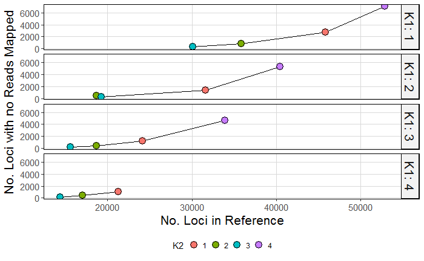

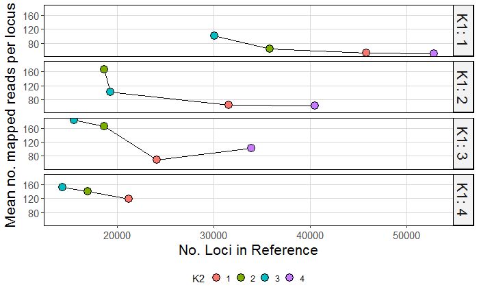

#### Evaluate & compare mapping results

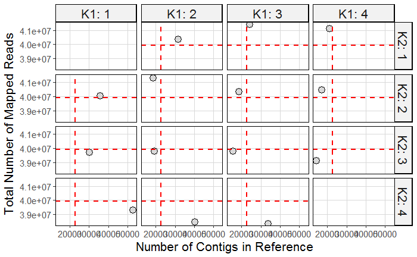

The number of reads that are mapped as a pair to the same locus varies with different combinations of K1 and K2.

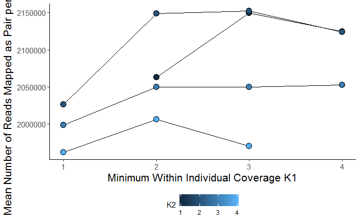

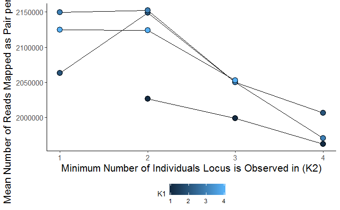

The number of reads where one mate of the pair is mapped to one reference contig and its mate mapped to another strongly depends on the combination of K1 and K2 values.

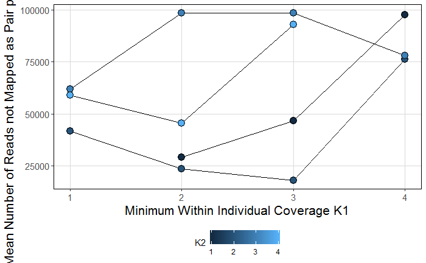

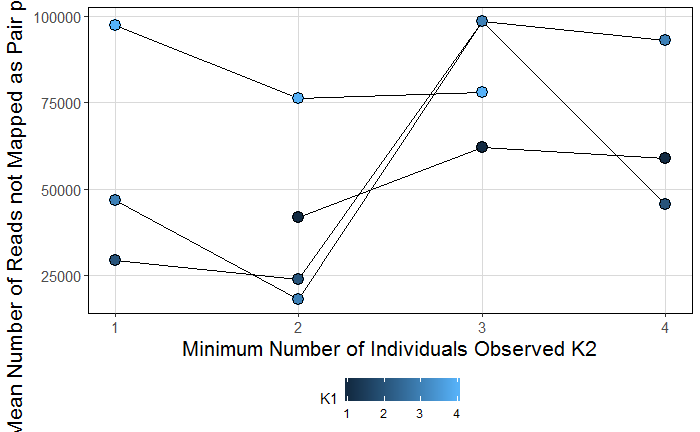

Cut-off values for K1 and K2 should be chosen to maximize the number of reads mapped to the reference and minimize the the number of reads not mapped as a proper pair.

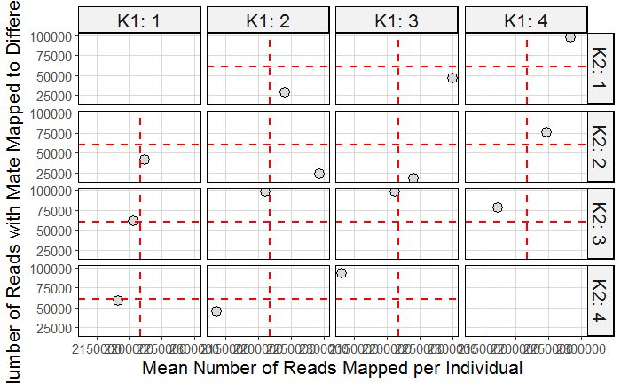

Choosing cut-off values for K1 and K2 are a trade-off between maximizing the number of reads in the reference and the number of reads mapped while minimizing the number of reads that are not mapped as a pair.

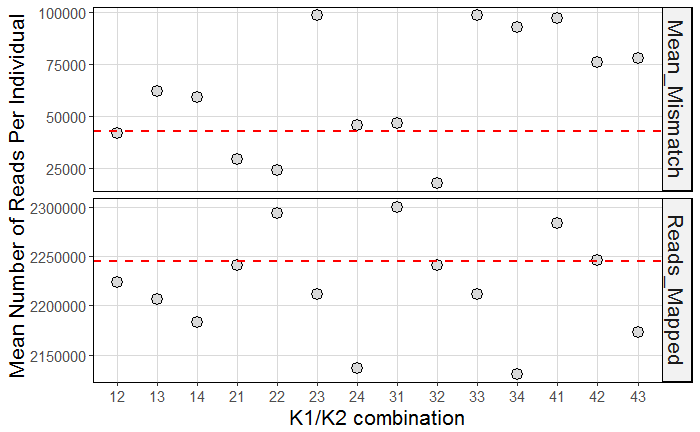

Reference below the dashed line (25th percentile) for mean number of mismatched paired reads and above the red dashed line (75th percentile) of mean number of reads mapped.

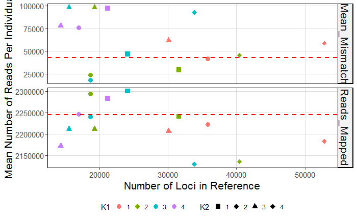